title: “AI Job Trends 2024” date: “2025-05-23” output: html_document: code_folding: none

```r
library(readxl)
library(dplyr)
library(ggplot2)
library(lubridate)

# Load the Excel file from your Desktop/Olga folder
df <- read_excel("/Users/olgacarrasco/Desktop/Olga/AI_ML_Jobs_US_2024.xlsx")
```

```r
df <- df %>%
  filter(!is.na(published_month))
  # Filter rows where published_month is not NA
```

## 1. Introduction

The AI job market has grown rapidly in recent years, driven by advances in machine learning, generative AI and automation technologies. This project analyzes AI-related job postings from 2022 to 2024 using a refined Kaggle dataset enhanced with additional skill and education indicators.

Key focus areas include identifying popular job titles, analyzing geographic and sector distributions, examining experience and education requirements and exploring demand for specific AI skills. These insights aim to help job seekers, educators and professionals understand current trends and skill demands in this fast-evolving field.

## 2. Dataset and Metodology

This analysis uses a modified version of the [Kaggle AI Job Listings Dataset](https://www.kaggle.com/datasets/kanchana1990/ai-and-ml-job-listings-usa), with added columns marking specific skills extracted from job descriptions. For analytical purposes, the various job titles have been grouped into specific categories to facilitate clearer insights. These categories include:

- **Generalist ML Engineers**
- **ML Engineer Software**
- **ML Engineer NLP, Generative AI, Deep Learning**
- **ML Engineer Ops (including Cloud & Big Data)**
- **ML Engineer Research (including Robotics)**
- **ML Engineer / Data Scientist**

This grouping allows for focused analysis of skills, education requirements and trends within each distinct AI job function.

The dataset covers job titles, locations, experience levels, education, skills and posting dates from 2022 through 2024.

## 3. Job Category Ranking

This section presents the distribution of job postings across predefined machine learning (ML) engineer categories. Rather than listing individual job titles, roles are grouped into broader categories such as Generalist, ML Engineer Software, NLP/Generative AI/Deep Learning and more. The goal is to provide a clearer picture of the AI job market’s structure.

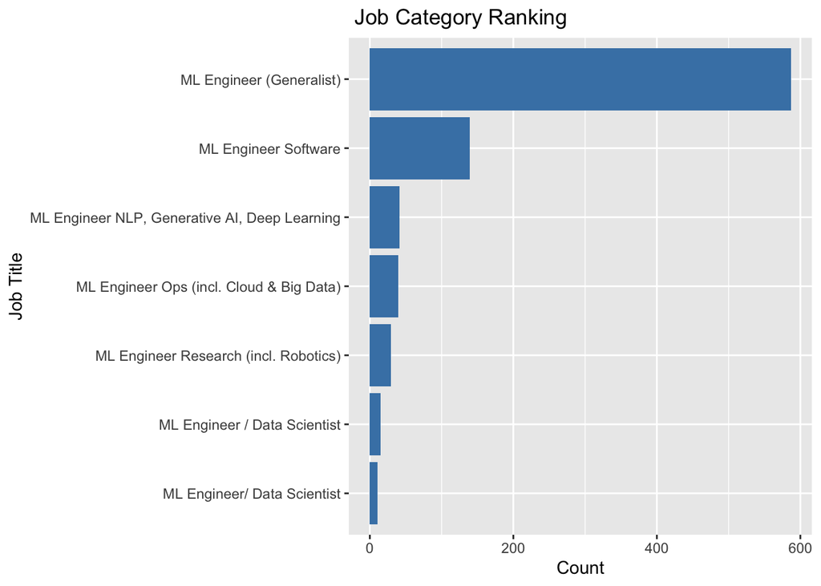

```r
df %>%
  count(edited_category, sort = TRUE) %>%
  top_n(10) %>%
  ggplot(aes(x = reorder(edited_category, n), y = n)) +
  geom_bar(stat = "identity", fill = "steelblue") +
  coord_flip() +
  labs(title = " Job Category Ranking", x = "Job Title", y = "Count")
```

The graph clearly shows that **ML Engineer Generalist** roles are the most predominant by a significant margin, followed distantly by **ML Engineer Software** positions. This suggests that most job listings do not specify a particular type of machine learning engineering, but rather seek professionals with broad, generalist skill sets. At the other end of the spectrum, the hybrid **ML Engineer / Data Scientist** category appears the least represented. However, it’s important to note that this dataset focuses specifically on ML Engineer roles. Pure Data Scientist positions were not included, and are likely in higher demand than what is reflected here.

## 4. Geographic Distribution

Geography plays a critical role in AI job availability. This section explores where these roles are concentrated across the U.S., highlighting the most active locations for ML hiring.

### 4.1 Top 10 States

Here, we identify the ten U.S. states with the highest number of AI-related job postings. This helps illustrate regional trends and states that serve as major hubs for AI talent.

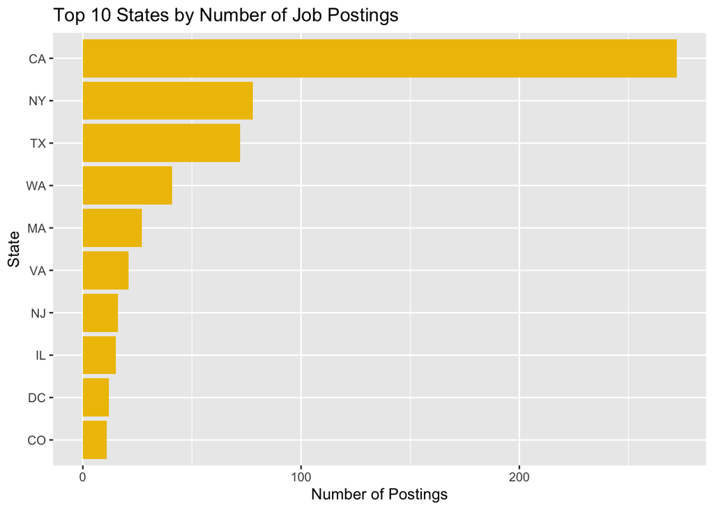

```r
df %>%
  filter(!is.na(state), state != "N/A") %>%
  count(state, sort = TRUE) %>%
  top_n(10) %>%
  ggplot(aes(x = reorder(state, n), y = n)) +
  geom_bar(stat = "identity", fill = "#EFC000FF") +
  coord_flip() +
  labs(title = "Top 10 States by Number of Job Postings", x = "State", y = "Number of Postings")
```

**California** clearly dominates AI job postings, underscoring its position as the primary tech hub in the US. **New York** holds second place, while **Texas** ranks third and is rapidly expanding its tech scene, particularly in cities like Austin. **Washington** comes in fourth, supported by major tech employers such as Microsoft and Amazon.

### 4.2 Top 10 Cities

This section dives deeper into the urban distribution of AI jobs, listing the top ten cities where ML job postings are most prevalent. These insights are useful for those considering relocation for career opportunities.

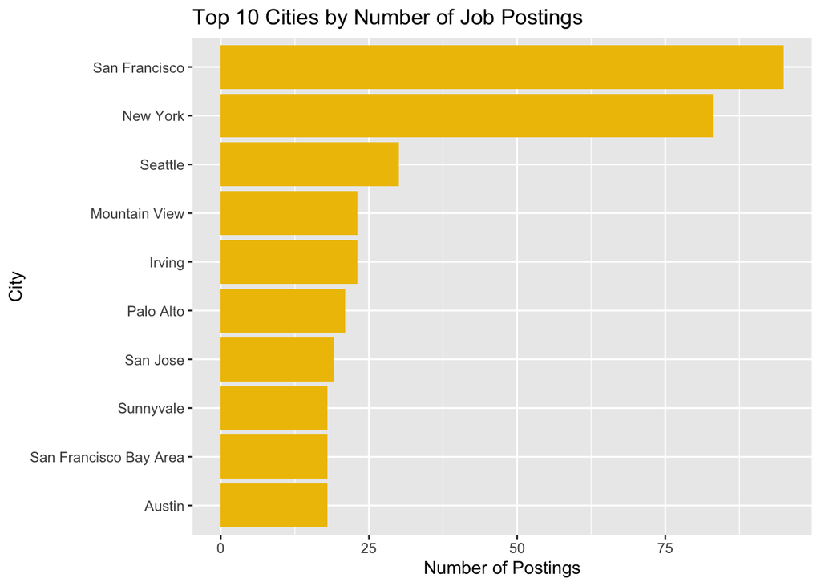

```r
df %>%
  filter(!is.na(city), city != "N/A") %>%
  count(city, sort = TRUE) %>%
  top_n(10) %>%
  ggplot(aes(x = reorder(city, n), y = n)) +
  geom_bar(stat = "identity", fill = "#EFC000FF") +
  coord_flip() +
  labs(title = "Top 10 Cities by Number of Job Postings", x = "City", y = "Number of Postings")
```

**San Francisco** and **New York** clearly lead the AI job market, reflecting their status as major tech and business hubs. Notably, there is a strong predominance of Californian cities in the list, including **Mountain View**, **Palo Alto**, **San Jose**, **Sunnyvale**, and the **San Francisco Bay Area**, highlighting Silicon Valley’s continued importance as a major tech hub. Other cities like **Seattle**, **Irving**, and **Austin** also appear, reflecting growing tech activity beyond California and the East Coast.

## 5. Job Postings by Sector

AI roles are in demand across various industries. This section breaks down job postings by sector (e.g., Tech, Finance, Recruiting) to show where AI talent is most sought after.

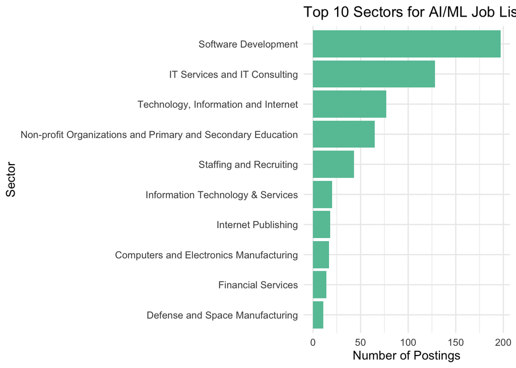

```r
df %>%
  filter(!is.na(sector)) %>%
  count(sector, sort = TRUE) %>%
  top_n(10) %>%
  ggplot(aes(x = reorder(sector, n), y = n)) +
  geom_col(fill = "#66c2a5") +
  coord_flip() +
  labs(
    title = "Top 10 Sectors for AI/ML Job Listings",
    x = "Sector",
    y = "Number of Postings"
  ) +
  theme_minimal(base_size = 12)
```

The distribution of AI job postings by sector shows a strong focus on **software development**, followed by **IT services and consulting**, and **technology, information and internet industries**. Interestingly, **nonprofit organizations and primary and secondary education** also feature prominently, indicating AI’s expanding role beyond traditional tech sectors. **Staffing and recruiting** ranks notably high, reflecting the active search for AI talent. While **defense and space manufacturing** sectors appear in the top 10, their share remains relatively small until 2024, highlighting a modest but ongoing investment in AI technologies.

## 6. Experience Level Distribution

Understanding what level of experience employers are seeking can help job seekers position themselves better. This section analyzes the distribution of postings across different experience levels, from entry-level to senior roles.

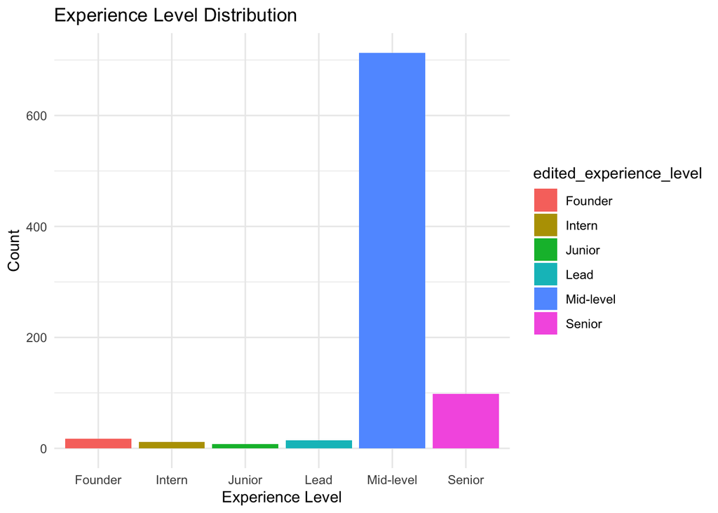

```r
df %>%
  count(edited_experience_level) %>%
  ggplot(aes(x = edited_experience_level, y = n, fill = edited_experience_level)) +
  geom_col() +
  labs(title = "Experience Level Distribution", x = "Experience Level", y = "Count") +
  theme_minimal()
```

The bar chart shows that **mid-level** experience is the most in demand, followed by **senior**, **founder**, and **lead positions**. It’s important to note that for job listings without a specified experience level, mid-level has been assigned by default.

## 7. Evolution Over Time

This section explores how AI job postings have evolved over time. By examining monthly trends we can identify hiring cycles, peak periods, and potential market shifts in AI demand.

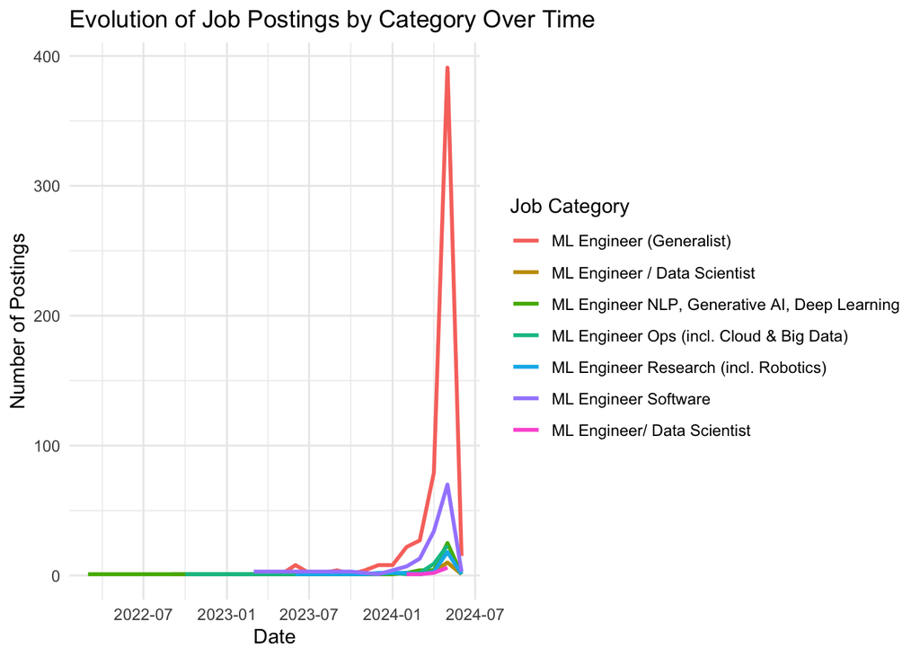

```r
df %>%
  group_by(published_year, published_month, edited_category) %>%
  summarise(postings = n()) %>%
  ungroup() %>%
  mutate(date = as.Date(paste(published_year, published_month, "01", sep = "-"))) %>%
  ggplot(aes(x = date, y = postings, color = edited_category)) +
  geom_line(size = 1) +
  labs(title = "Evolution of Job Postings by Category Over Time",
       x = "Date",
       y = "Number of Postings",
       color = "Job Category") +
  theme_minimal()
```

- **A renewed industry push for AI talent**, possibly driven by recent technological advancements and increased market demand.
- **Major events in the AI space** such as **product launches** (e.g., GPT-4o), **regulatory developments**, or **large-scale investment announcements**.
- However, given the magnitude of the spike, jumping from under 100 to around 400 postings in a short period, it is most likely due to the **dataset’s collection method**. A temporary increase in scraping activity or a change in coverage may have caused an unusually high number of listings to be captured during that month.

The overall pattern appears **consistent across most job categories**.

## 8. Education Requirements

This section summarizes which educational backgrounds are most commonly required for AI roles. The focus is on core disciplines like computer science, software engineering, electrical engineering and statistics.

### 8.1 Generalist ML Engineers

We analyze education trends for Generalist ML Engineer roles, highlighting which qualifications are most often required in these versatile positions.

```r
library(dplyr)
library(tidyr)
library(stringr)
library(DT)

education_generalist <- df %>%
  filter(str_detect(edited_category, "Generalist")) %>%
  select(
    edited_education_computer_science,
    edited_education_software_engineering,
    edited_education_electrical_engineering,
    edited_education_other_engineering,
    edited_education_statistics,
    edited_education_mathematics,
    edited_education_physics,
    edited_education_unspecified
  ) %>%
  rename(
    `Computer Science` = edited_education_computer_science,
    `Software Engineering` = edited_education_software_engineering,
    `Electrical Engineering` = edited_education_electrical_engineering,
    `Core Engineering` = edited_education_other_engineering,
    `Statistics` = edited_education_statistics,
    `Mathematics` = edited_education_mathematics,
    `Physics` = edited_education_physics,
    `Unspecified` = edited_education_unspecified
  ) %>%
  pivot_longer(
    cols = everything(),
    names_to = "Education",
    values_to = "Required"
  ) %>%
  filter(Required == TRUE) %>%
  count(Education, name = "Count") %>%
  arrange(desc(Count)) %>%
  mutate(
    Percent = paste0(round(Count / sum(Count) * 100), "%")
  ) %>%
  select(Education, Percent)

datatable_obj <- DT::datatable(
  education_generalist,
  options = list(
    pageLength = 15,
    scrollX = TRUE,
    headerCallback = JS(
      "function(thead, data, start, end, display){",
      "  $(thead).find('th').eq(1).css('text-align', 'right');",
      "}"
    )
  ),
  rownames = FALSE
) %>%
  DT::formatStyle(
    'Percent',
    'text-align' = 'right'
  )

datatable_obj
```

| Education | Percent |
| --- | --- |
| Computer Science | 27% |
| Core Engineering | 27% |
| Software Engineering | 16% |
| Statistics | 15% |
| Mathematics | 6% |
| Physics | 4% |
| Electrical Engineering | 2% |
| Unspecified | 2% |

Generalist ML Engineers primarily come from **Computer Science (27%)** and **Core Engineering (27%)**, showing a strong preference for technical and engineering backgrounds. **Software Engineering (16%)** and **Statistics (15%)** follow, emphasizing programming and data skills. Fewer come from **Mathematics (6%)**, **Physics (4%)**, and **Electrical Engineering (2%)**, while **2% have unspecified** education, indicating a small portion with nontraditional or unclear paths.

### 8.2. ML Engineer Software

This section focuses on ML roles that emphasize software development. It examines which educational backgrounds are favored for building ML applications and infrastructure.

```r
library(dplyr)
library(tidyr)
library(stringr)
library(DT)

education_software <- df %>%
  filter(edited_category == "ML Engineer Software") %>%
  select(
    edited_education_computer_science,
    edited_education_software_engineering,
    edited_education_electrical_engineering,
    edited_education_other_engineering,
    edited_education_statistics,
    edited_education_mathematics,
    edited_education_physics,
    edited_education_unspecified
  ) %>%
  rename(
    `Computer Science` = edited_education_computer_science,
    `Software Engineering` = edited_education_software_engineering,
    `Electrical Engineering` = edited_education_electrical_engineering,
    `Core Engineering` = edited_education_other_engineering,
    `Statistics` = edited_education_statistics,
    `Mathematics` = edited_education_mathematics,
    `Physics` = edited_education_physics,
    `Unspecified` = edited_education_unspecified
  ) %>%
  pivot_longer(cols = everything(), names_to = "Education", values_to = "Required") %>%
  filter(Required) %>%
  count(Education, name = "Count") %>%
  arrange(desc(Count)) %>%
  mutate(
    Percent = paste0(round(Count / sum(Count) * 100), "%")
  ) %>%
  select(Education, Percent)

datatable_obj <- datatable(
  education_software,
  options = list(
    pageLength = 15,
    scrollX = TRUE,
    headerCallback = DT::JS(
      "function(thead, data, start, end, display){",
      "  $(thead).find('th').eq(1).css('text-align', 'right');",
      "}"
    )
  ),
  rownames = FALSE
) %>%
  formatStyle(
    'Percent',
    'text-align' = 'right'
  )

datatable_obj
```

| Education | Percent |
| --- | --- |
| Core Engineering | 33% |
| Computer Science | 29% |
| Software Engineering | 22% |
| Mathematics | 6% |
| Statistics | 6% |
| Unspecified | 2% |
| Physics | 1% |
| Electrical Engineering | 0% |

Compared to Generalist ML Engineers, ML Engineers in Software show a strong emphasis on **Core Engineering (33%)**, followed by **Computer Science (29%)** and **Software Engineering (22%)**. While it may seem surprising that Software Engineering ranks third, this likely reflects the job title already **implies a software background**, leading to generalization or omission in reporting. Fields like **Mathematics (6%)** and **Statistics (6%)** are less prominent, while **Unspecified (2%)** and **Physics (1%)** represent very small shares. Electrical Engineering is not represented in this group.

### 8.3 ML Engineer NLP, Generative AI, Deep Learning

This section focuses on roles centered around natural language processing, generative AI and deep learning.

```r
library(dplyr)
library(tidyr)
library(stringr)
library(DT)

education_nlp <- df %>%
  filter(edited_category == "ML Engineer NLP, Generative AI, Deep Learning") %>%
  select(
    edited_education_computer_science,
    edited_education_software_engineering,
    edited_education_electrical_engineering,
    edited_education_other_engineering,
    edited_education_statistics,
    edited_education_mathematics,
    edited_education_physics,
    edited_education_unspecified
  ) %>%
  rename(
    `Computer Science` = edited_education_computer_science,
    `Software Engineering` = edited_education_software_engineering,
    `Electrical Engineering` = edited_education_electrical_engineering,
    `Core Engineering` = edited_education_other_engineering,
    `Statistics` = edited_education_statistics,
    `Mathematics` = edited_education_mathematics,
    `Physics` = edited_education_physics,
    `Unspecified` = edited_education_unspecified
  ) %>%
  pivot_longer(cols = everything(), names_to = "Education", values_to = "Required") %>%
  filter(Required) %>%
  count(Education, name = "Count") %>%
  arrange(desc(Count)) %>%
  mutate(
    Percent = paste0(round(Count / sum(Count) * 100), "%")
  ) %>%
  select(Education, Percent)

datatable_obj <- datatable(
  education_nlp,
  options = list(
    pageLength = 15,
    scrollX = TRUE,
    headerCallback = DT::JS(
      "function(thead, data, start, end, display){",
      "  $(thead).find('th').eq(1).css('text-align', 'right');",
      "}"
    )
  ),
  rownames = FALSE
) %>%
  formatStyle(
    'Percent',
    'text-align' = 'right'
  )

datatable_obj
```

| Education | Percent |
| --- | --- |
| Core Engineering | 32% |
| Computer Science | 21% |
| Software Engineering | 19% |
| Statistics | 11% |
| Electrical Engineering | 7% |
| Mathematics | 5% |
| Unspecified | 4% |
| Physics | 1% |

This group shows a more balanced distribution across technical fields. **Core Engineering (32%)**, **Computer Science (21%)** and **Software Engineering (19%)** remain strong. Fields such as **Statistics (11%)**, **Electrical Engineering (7%)**, **Mathematics (5%)**, and **Physics (1%)** are modestly represented, indicating a smaller influence of theoretical backgrounds in this specialized area.

### 8.4 ML Engineer Ops (incl. Cloud & Big Data)

This section examines education requirements for ML operational roles, which are those that involve deploying models, working with cloud platforms and managing big data pipelines.

```r
library(dplyr)
library(tidyr)
library(stringr)
library(DT)

education_ops <- df %>%
  filter(edited_category == "ML Engineer Ops (incl. Cloud & Big Data)") %>%
  select(
    edited_education_computer_science,
    edited_education_software_engineering,
    edited_education_electrical_engineering,
    edited_education_other_engineering,
    edited_education_statistics,
    edited_education_mathematics,
    edited_education_physics,
    edited_education_unspecified
  ) %>%
  rename(
    `Computer Science` = edited_education_computer_science,
    `Software Engineering` = edited_education_software_engineering,
    `Electrical Engineering` = edited_education_electrical_engineering,
    `Core Engineering` = edited_education_other_engineering,
    `Statistics` = edited_education_statistics,
    `Mathematics` = edited_education_mathematics,
    `Physics` = edited_education_physics,
    `Unspecified` = edited_education_unspecified
  ) %>%
  pivot_longer(cols = everything(), names_to = "Education", values_to = "Required") %>%
  filter(Required) %>%
  count(Education, name = "Count") %>%
  arrange(desc(Count)) %>%
  mutate(
    Percent = paste0(round(Count / sum(Count) * 100), "%")
  ) %>%
  select(Education, Percent)

datatable_obj <- datatable(
  education_ops,
  options = list(
    pageLength = 15,
    scrollX = TRUE,
    headerCallback = DT::JS(
      "function(thead, data, start, end, display){",
      "  $(thead).find('th').eq(1).css('text-align', 'right');",
      "}"
    )
  ),
  rownames = FALSE
) %>%
  formatStyle(
    'Percent',
    'text-align' = 'right'
  )

datatable_obj
```

| Education | Percent |
| --- | --- |
| Computer Science | 33% |
| Core Engineering | 30% |
| Software Engineering | 20% |
| Mathematics | 8% |
| Statistics | 7% |
| Electrical Engineering | 1% |
| Unspecified | 1% |

For **ML Engineer Ops roles (including Cloud & Big Data)**, there is a notably stronger presence of **Computer Science (33%)** compared to other specialized ML positions, likely reflecting the technical demands involved in infrastructure, cloud platforms, and large-scale data systems. **Core Engineering (30%)** and **Software Engineering (20%)** also remain prominent, underscoring the importance of broad and applied engineering skills in this space. **Mathematics (8%)** and **Statistics (7%)** play a more modest role, while **Electrical Engineering (1%)** is nearly absent, which is unsurprising for an ops-focused role.

### 8.5 ML Engineer Research (incl. Robotics)

Research-oriented ML roles typically require advanced academic backgrounds. This section investigates which degrees are most commonly requested in these cutting-edge positions.

```r
library(dplyr)
library(tidyr)
library(stringr)
library(DT)

education_research <- df %>%
  filter(edited_category == "ML Engineer Research (incl. Robotics)") %>%
  select(
    edited_education_computer_science,
    edited_education_software_engineering,
    edited_education_electrical_engineering,
    edited_education_other_engineering,
    edited_education_statistics,
    edited_education_mathematics,
    edited_education_physics,
    edited_education_unspecified
  ) %>%
  rename(
    `Computer Science` = edited_education_computer_science,
    `Software Engineering` = edited_education_software_engineering,
    `Electrical Engineering` = edited_education_electrical_engineering,
    `Core Engineering` = edited_education_other_engineering,
    `Statistics` = edited_education_statistics,
    `Mathematics` = edited_education_mathematics,
    `Physics` = edited_education_physics,
    `Unspecified` = edited_education_unspecified
  ) %>%
  pivot_longer(cols = everything(), names_to = "Education", values_to = "Required") %>%
  filter(Required) %>%
  count(Education, name = "Count") %>%
  arrange(desc(Count)) %>%
  mutate(
    Percent = paste0(round(Count / sum(Count) * 100), "%")
  ) %>%
  select(Education, Percent)

datatable_obj <- datatable(
  education_research,
  options = list(
    pageLength = 15,
    scrollX = TRUE,
    headerCallback = DT::JS(
      "function(thead, data, start, end, display){",
      "  $(thead).find('th').eq(1).css('text-align', 'right');",
      "}"
    )
  ),
  rownames = FALSE
) %>%
  formatStyle(
    'Percent',
    'text-align' = 'right'
  )

datatable_obj
```

| Education | Percent |
| --- | --- |
| Core Engineering | 30% |
| Computer Science | 25% |
| Software Engineering | 12% |
| Statistics | 11% |
| Electrical Engineering | 7% |
| Mathematics | 5% |
| Physics | 5% |
| Unspecified | 5% |

Research-focused ML roles, including robotics, emphasize **strong academic backgrounds**. **Core Engineering (30%)** and **Computer Science (25%)** dominate, reflecting the need for solid **engineering and computing foundations**. **Software Engineering (12%)** and **Statistics (11%)** are also important, highlighting the role of software development and advanced data analysis. Electrical Engineering, Mathematics and Physics each contribute modestly, showing the interdisciplinary nature of these cutting-edge positions.

### 8.6 ML Engineer / Data Scientist

In this hybrid category we explore the education trends behind roles that blend machine learning engineering and data science skills.

```r
library(dplyr)
library(tidyr)
library(stringr)
library(DT)

education_ml_ds <- df %>%
  filter(edited_category == "ML Engineer / Data Scientist") %>%
  select(
    edited_education_computer_science,
    edited_education_software_engineering,
    edited_education_electrical_engineering,
    edited_education_other_engineering,
    edited_education_statistics,
    edited_education_mathematics,
    edited_education_physics,
    edited_education_unspecified
  ) %>%
  rename(
    `Computer Science` = edited_education_computer_science,
    `Software Engineering` = edited_education_software_engineering,
    `Electrical Engineering` = edited_education_electrical_engineering,
    `Core Engineering` = edited_education_other_engineering,
    `Statistics` = edited_education_statistics,
    `Mathematics` = edited_education_mathematics,
    `Physics` = edited_education_physics,
    `Unspecified` = edited_education_unspecified
  ) %>%
  pivot_longer(cols = everything(), names_to = "Education", values_to = "Required") %>%
  filter(Required) %>%
  count(Education, name = "Count") %>%
  arrange(desc(Count)) %>%
  mutate(
    Percent = paste0(round(Count / sum(Count) * 100), "%")
  ) %>%
  select(Education, Percent)

datatable_obj <- datatable(
  education_ml_ds,
  options = list(
    pageLength = 15,
    scrollX = TRUE,
    headerCallback = DT::JS(
      "function(thead, data, start, end, display){",
      "  $(thead).find('th').eq(1).css('text-align', 'right');",
      "}"
    )
  ),
  rownames = FALSE
) %>%
  formatStyle(
    'Percent',
    'text-align' = 'right'
  )

datatable_obj
```

| Education | Percent |
| --- | --- |
| Core Engineering | 42% |
| Statistics | 28% |
| Computer Science | 19% |
| Mathematics | 6% |
| Physics | 6% |

ML Engineer / Data Scientist roles prioritize **Core Engineering (42%)** and **Statistics (28%)**, underscoring the importance of **applied engineering skills** and **strong statistical knowledge**. **Computer Science (19%)** remains relevant, reflecting the role’s technical demands. **Mathematics (6%)** and **Physics (6%)** also contribute, indicating the value of quantitative and analytical foundations in this data-driven field.

## 9. Top Skills Across All Categories

What technical skills are most in demand? This section aggregates the frequency of various AI-related skills across all job postings, highlighting the most sought-after competencies in today’s market.

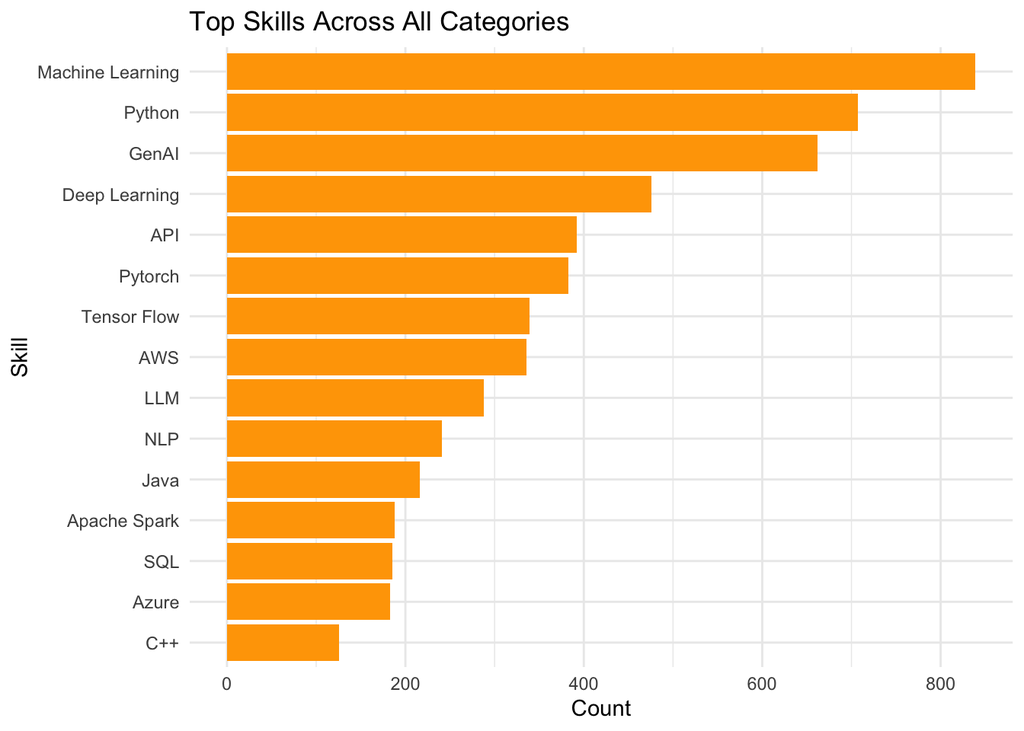

```r
library(dplyr)
library(tidyr)
library(stringr)
library(ggplot2)

skill_counts <- df %>%
  select(
    edited_skills_coding_phyton,
    edited_skills_coding_java,
    edited_skills_coding_cpp,
    edited_skills_coding_sql,
    edited_skills_category_machine_learning,
    edited_skills_category_deep_learning,
    edited_skills_category_LLM,
    edited_skills_category_NLP,
    edited_skills_category_generative_AI,
    edited_skills_category_api,
    edited_skills_category_back_end,
    edited_skills_category_front_end,
    edited_skills_category_full_stack,
    edited_skills_tools_tensor_flow,
    edited_skills_tools_apache_spark,
    edited_skills_tools_pytorch,
    edited_skills_tools_keras,
    edited_skills_tools_Scikit_learn,
    edited_skills_tools_XGBoost,
    edited_skills_tools_AWS,
    edited_skills_tools_Google_Cloud,
    edited_skills_tools_Azure
  ) %>%
  rename(
    `Python` = edited_skills_coding_phyton,
    `Java` = edited_skills_coding_java,
    `C++`= edited_skills_coding_cpp,
    `SQL`= edited_skills_coding_sql,
    `Machine Learning` = edited_skills_category_machine_learning,
    `Deep Learning`= edited_skills_category_deep_learning,
    `LLM` = edited_skills_category_LLM,
    `NLP` = edited_skills_category_NLP,
    `GenAI` = edited_skills_category_generative_AI,
    `API` = edited_skills_category_api,
    `Back-End`= edited_skills_category_back_end,
    `Front-End`= edited_skills_category_front_end,
    `Full-Stack`= edited_skills_category_full_stack,
    `Tensor Flow` = edited_skills_tools_tensor_flow,
    `Apache Spark`= edited_skills_tools_apache_spark,
    `Pytorch`= edited_skills_tools_pytorch,
    `Keras`= edited_skills_tools_keras,
    `Scikit Learn`= edited_skills_tools_Scikit_learn,
    `XGBoost`= edited_skills_tools_XGBoost,
    `AWS`= edited_skills_tools_AWS,
    `Google Cloud`= edited_skills_tools_Google_Cloud,
    `Azure`= edited_skills_tools_Azure
  ) %>%
  pivot_longer(
    cols = everything(),
    names_to = "Skill",
    values_to = "Required"
  ) %>%
  filter(Required == TRUE) %>%
  count(Skill, name = "Count") %>%
  arrange(desc(Count))

# Plot top skills with orange bars
skill_counts %>%
  top_n(15, wt = Count) %>%
  ggplot(aes(x = reorder(Skill, Count), y = Count)) +
  geom_bar(stat = "identity", fill = "orange") +
  coord_flip() +
  labs(
    title = "Top Skills Across All Categories",
    x = "Skill",
    y = "Count"
  ) +
  theme_minimal()
```

The most recurring 22 skills are displayed in the table below.

```r
library(dplyr)
library(tidyr)
library(stringr)
library(DT)

skill_counts <- df %>%
  select(
    edited_skills_coding_phyton,
    edited_skills_coding_java,
    edited_skills_coding_cpp,
    edited_skills_coding_sql,
    edited_skills_category_machine_learning,
    edited_skills_category_deep_learning,
    edited_skills_category_LLM,
    edited_skills_category_NLP,
    edited_skills_category_generative_AI,
    edited_skills_category_api,
    edited_skills_category_back_end,
    edited_skills_category_front_end,
    edited_skills_category_full_stack,
    edited_skills_tools_tensor_flow,
    edited_skills_tools_apache_spark,
    edited_skills_tools_pytorch,
    edited_skills_tools_keras,
    edited_skills_tools_Scikit_learn,
    edited_skills_tools_XGBoost,
    edited_skills_tools_AWS,
    edited_skills_tools_Google_Cloud,
    edited_skills_tools_Azure
  ) %>%
  rename(
    `Python` = edited_skills_coding_phyton,
    `Java` = edited_skills_coding_java,
    `C++`= edited_skills_coding_cpp,
    `SQL`= edited_skills_coding_sql,
    `Machine Learning` = edited_skills_category_machine_learning,
    `Deep Learning`= edited_skills_category_deep_learning,
    `LLM` = edited_skills_category_LLM,
    `NLP` = edited_skills_category_NLP,
    `GenAI` = edited_skills_category_generative_AI,
    `API` = edited_skills_category_api,
    `Back-End`= edited_skills_category_back_end,
    `Front-End`= edited_skills_category_front_end,
    `Full-Stack`= edited_skills_category_full_stack,
    `Tensor Flow` = edited_skills_tools_tensor_flow,
    `Apache Spark`= edited_skills_tools_apache_spark,
    `Pytorch`= edited_skills_tools_pytorch,
    `Keras`= edited_skills_tools_keras,
    `Scikit Learn`= edited_skills_tools_Scikit_learn,
    `XGBoost`= edited_skills_tools_XGBoost,
    `AWS`= edited_skills_tools_AWS,
    `Google Cloud`= edited_skills_tools_Google_Cloud,
    `Azure`= edited_skills_tools_Azure
  ) %>%
  pivot_longer(
    cols = everything(),
    names_to = "Skill",
    values_to = "Required"
  ) %>%
  filter(Required == TRUE) %>%
  count(Skill, name = "Count") %>%
  arrange(desc(Count))

# Render scrollable table
datatable(skill_counts,
          options = list(pageLength = 10, scrollX = TRUE),
          rownames = FALSE)
```

| Skill | Count |
| --- | --- |
| Machine Learning | 839 |
| Python | 707 |
| GenAI | 662 |
| Deep Learning | 476 |
| API | 392 |
| Pytorch | 383 |
| Tensor Flow | 339 |
| AWS | 336 |
| LLM | 288 |
| NLP | 241 |

[output cut: 12 more lines]

## 10. Skills per Job Category

To better understand how skill demands differ across job types, this section breaks down skill requirements by job category.

### 10.1. Generalist ML Engineers

We explore the core skill set expected from generalist roles, including programming languages and AI toolkits.

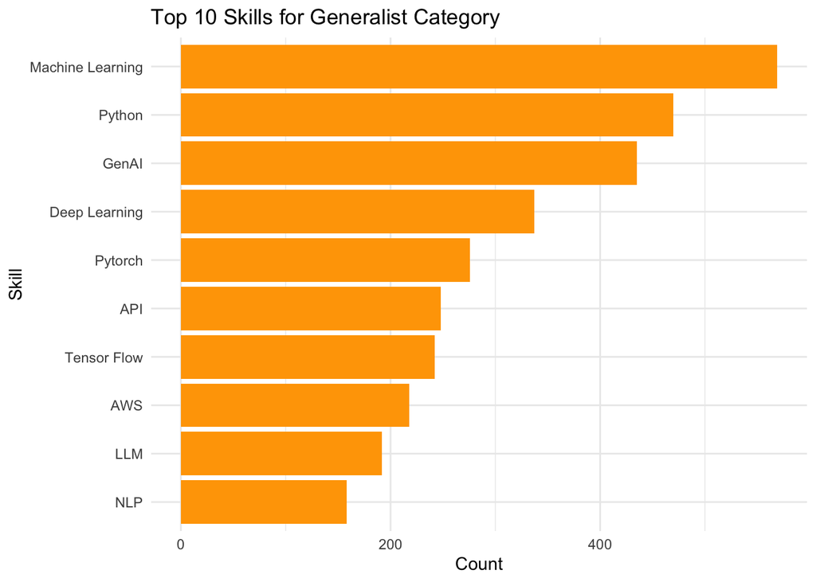

```r
library(dplyr)
library(tidyr)
library(stringr)
library(ggplot2)

skill_counts <- df %>%
  filter(str_detect(edited_category, "Generalist")) %>%
  select(
    edited_skills_coding_phyton,
    edited_skills_coding_java,
    edited_skills_coding_cpp,
    edited_skills_coding_sql,
    edited_skills_category_machine_learning,
    edited_skills_category_deep_learning,
    edited_skills_category_LLM,
    edited_skills_category_NLP,
    edited_skills_category_generative_AI,
    edited_skills_category_api,
    edited_skills_category_back_end,
    edited_skills_category_front_end,
    edited_skills_category_full_stack,
    edited_skills_tools_tensor_flow,
    edited_skills_tools_apache_spark,
    edited_skills_tools_pytorch,
    edited_skills_tools_keras,
    edited_skills_tools_Scikit_learn,
    edited_skills_tools_XGBoost,
    edited_skills_tools_AWS,
    edited_skills_tools_Google_Cloud,
    edited_skills_tools_Azure
  ) %>%
  rename(
    `Python` = edited_skills_coding_phyton,
    `Java` = edited_skills_coding_java,
    `C++`= edited_skills_coding_cpp,
    `SQL`= edited_skills_coding_sql,
    `Machine Learning` = edited_skills_category_machine_learning,
    `Deep Learning`= edited_skills_category_deep_learning,
    `LLM` = edited_skills_category_LLM,
    `NLP` = edited_skills_category_NLP,
    `GenAI` = edited_skills_category_generative_AI,
    `API` = edited_skills_category_api,
    `Back-End`= edited_skills_category_back_end,
    `Front-End`= edited_skills_category_front_end,
    `Full-Stack`= edited_skills_category_full_stack,
    `Tensor Flow` = edited_skills_tools_tensor_flow,
    `Apache Spark`= edited_skills_tools_apache_spark,
    `Pytorch`= edited_skills_tools_pytorch,
    `Keras`= edited_skills_tools_keras,
    `Scikit Learn`= edited_skills_tools_Scikit_learn,
    `XGBoost`= edited_skills_tools_XGBoost,
    `AWS`= edited_skills_tools_AWS,
    `Google Cloud`= edited_skills_tools_Google_Cloud,
    `Azure`= edited_skills_tools_Azure
  ) %>%
  pivot_longer(
    cols = everything(),
    names_to = "Skill",
    values_to = "Required"
  ) %>%
  filter(Required == TRUE) %>%
  count(Skill, name = "Count") %>%
  arrange(desc(Count))

# Now plot the top 15 skills with orange bars
skill_counts %>%
  top_n(10, wt = Count) %>%
  ggplot(aes(x = reorder(Skill, Count), y = Count)) +
  geom_bar(stat = "identity", fill = "orange") +
  coord_flip() +
  labs(
    title = "Top 10 Skills for Generalist Category",
    x = "Skill",
    y = "Count"
  ) +
  theme_minimal()
```

Generalist ML Engineers focus heavily on **Machine Learning** and **Python**, more than in the general skill set. They emphasize **Generative AI, Deep Learning** and frameworks like **PyTorch** and **TensorFlow**. Skills such as **API** and **AWS** reflect practical, applied expertise. This mix shows generalists balance core ML knowledge with cutting-edge tools and real-world application.

### 10.2. ML Engineer Software

This section looks at software-focused roles, emphasizing skills related to backend development, APIs and full-stack engineering.

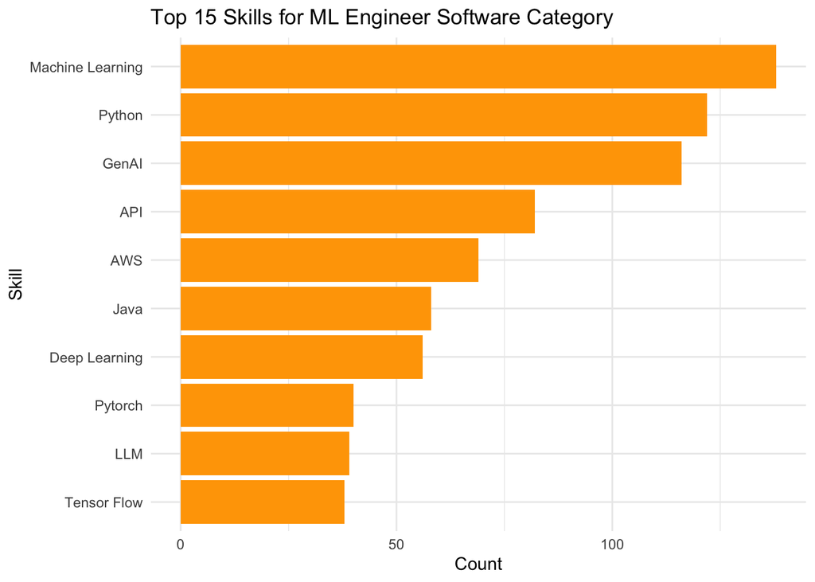

```r
library(dplyr)
library(tidyr)
library(stringr)
library(ggplot2)

skill_counts <- df %>%
  filter(str_detect(edited_category, "ML Engineer Software")) %>%
  select(
    edited_skills_coding_phyton,
    edited_skills_coding_java,
    edited_skills_coding_cpp,
    edited_skills_coding_sql,
    edited_skills_category_machine_learning,
    edited_skills_category_deep_learning,
    edited_skills_category_LLM,
    edited_skills_category_NLP,
    edited_skills_category_generative_AI,
    edited_skills_category_api,
    edited_skills_category_back_end,
    edited_skills_category_front_end,
    edited_skills_category_full_stack,
    edited_skills_tools_tensor_flow,
    edited_skills_tools_apache_spark,
    edited_skills_tools_pytorch,
    edited_skills_tools_keras,
    edited_skills_tools_Scikit_learn,
    edited_skills_tools_XGBoost,
    edited_skills_tools_AWS,
    edited_skills_tools_Google_Cloud,
    edited_skills_tools_Azure
  ) %>%
  rename(
    `Python` = edited_skills_coding_phyton,
    `Java` = edited_skills_coding_java,
    `C++`= edited_skills_coding_cpp,
    `SQL`= edited_skills_coding_sql,
    `Machine Learning` = edited_skills_category_machine_learning,
    `Deep Learning`= edited_skills_category_deep_learning,
    `LLM` = edited_skills_category_LLM,
    `NLP` = edited_skills_category_NLP,
    `GenAI` = edited_skills_category_generative_AI,
    `API` = edited_skills_category_api,
    `Back-End`= edited_skills_category_back_end,
    `Front-End`= edited_skills_category_front_end,
    `Full-Stack`= edited_skills_category_full_stack,
    `Tensor Flow` = edited_skills_tools_tensor_flow,
    `Apache Spark`= edited_skills_tools_apache_spark,
    `Pytorch`= edited_skills_tools_pytorch,
    `Keras`= edited_skills_tools_keras,
    `Scikit Learn`= edited_skills_tools_Scikit_learn,
    `XGBoost`= edited_skills_tools_XGBoost,
    `AWS`= edited_skills_tools_AWS,
    `Google Cloud`= edited_skills_tools_Google_Cloud,
    `Azure`= edited_skills_tools_Azure
  ) %>%
  pivot_longer(
    cols = everything(),
    names_to = "Skill",
    values_to = "Required"
  ) %>%
  filter(Required == TRUE) %>%
  count(Skill, name = "Count") %>%
  arrange(desc(Count))

# Now plot the top 15 skills with orange bars
skill_counts %>%
  top_n(10, wt = Count) %>%
  ggplot(aes(x = reorder(Skill, Count), y = Count)) +
  geom_bar(stat = "identity", fill = "orange") +
  coord_flip() +
  labs(
    title = "Top 15 Skills for ML Engineer Software Category",
    x = "Skill",
    y = "Count"
  ) +
  theme_minimal()
```

ML Engineer Software roles prioritize **Machine Learning** and **Python**, similar to generalists, but place a stronger emphasis on **Generative AI, API and AWS**, reflecting a focus on software infrastructure and cloud services. Programming languages like **Java** also rank higher, highlighting the software engineering aspect. Core ML skills such as **Deep Learning, PyTorch** and **TensorFlow** remain important but secondary.

### 10.3. ML Engineer NLP, Generative AI, Deep Learning

These highly specialized roles often call for expertise in LLMs, NLP and generative AI. We examine the technical requirements unique to these positions.

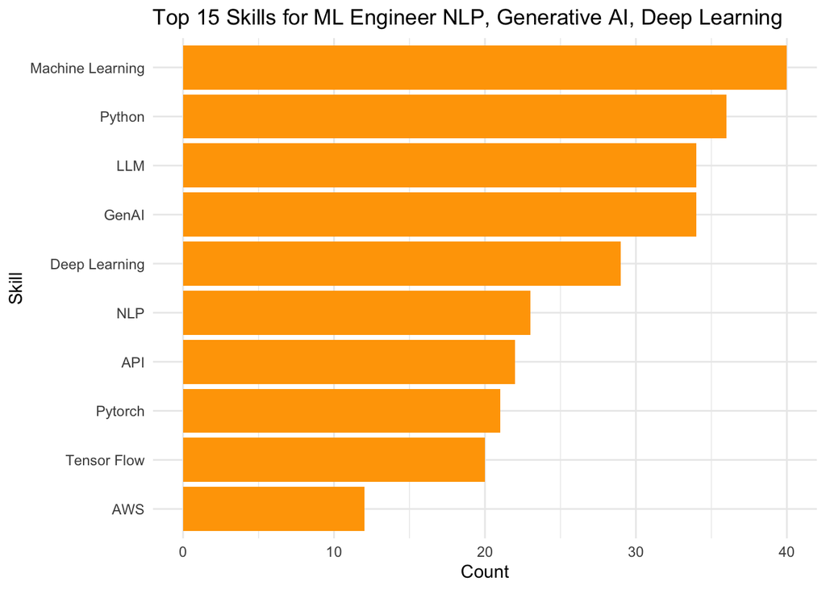

```r
library(dplyr)
library(tidyr)
library(stringr)
library(ggplot2)

skill_counts <- df %>%
  filter(str_detect(edited_category, "ML Engineer NLP, Generative AI, Deep Learning")) %>%
  select(
    edited_skills_coding_phyton,
    edited_skills_coding_java,
    edited_skills_coding_cpp,
    edited_skills_coding_sql,
    edited_skills_category_machine_learning,
    edited_skills_category_deep_learning,
    edited_skills_category_LLM,
    edited_skills_category_NLP,
    edited_skills_category_generative_AI,
    edited_skills_category_api,
    edited_skills_category_back_end,
    edited_skills_category_front_end,
    edited_skills_category_full_stack,
    edited_skills_tools_tensor_flow,
    edited_skills_tools_apache_spark,
    edited_skills_tools_pytorch,
    edited_skills_tools_keras,
    edited_skills_tools_Scikit_learn,
    edited_skills_tools_XGBoost,
    edited_skills_tools_AWS,
    edited_skills_tools_Google_Cloud,
    edited_skills_tools_Azure
  ) %>%
  rename(
    `Python` = edited_skills_coding_phyton,
    `Java` = edited_skills_coding_java,
    `C++`= edited_skills_coding_cpp,
    `SQL`= edited_skills_coding_sql,
    `Machine Learning` = edited_skills_category_machine_learning,
    `Deep Learning`= edited_skills_category_deep_learning,
    `LLM` = edited_skills_category_LLM,
    `NLP` = edited_skills_category_NLP,
    `GenAI` = edited_skills_category_generative_AI,
    `API` = edited_skills_category_api,
    `Back-End`= edited_skills_category_back_end,
    `Front-End`= edited_skills_category_front_end,
    `Full-Stack`= edited_skills_category_full_stack,
    `Tensor Flow` = edited_skills_tools_tensor_flow,
    `Apache Spark`= edited_skills_tools_apache_spark,
    `Pytorch`= edited_skills_tools_pytorch,
    `Keras`= edited_skills_tools_keras,
    `Scikit Learn`= edited_skills_tools_Scikit_learn,
    `XGBoost`= edited_skills_tools_XGBoost,
    `AWS`= edited_skills_tools_AWS,
    `Google Cloud`= edited_skills_tools_Google_Cloud,
    `Azure`= edited_skills_tools_Azure
  ) %>%
  pivot_longer(
    cols = everything(),
    names_to = "Skill",
    values_to = "Required"
  ) %>%
  filter(Required == TRUE) %>%
  count(Skill, name = "Count") %>%
  arrange(desc(Count))

# Now plot the top 15 skills with orange bars
skill_counts %>%
  top_n(10, wt = Count) %>%
  ggplot(aes(x = reorder(Skill, Count), y = Count)) +
  geom_bar(stat = "identity", fill = "orange") +
  coord_flip() +
  labs(
    title = "Top 15 Skills for ML Engineer NLP, Generative AI, Deep Learning",
    x = "Skill",
    y = "Count"
  ) +
  theme_minimal()
```

ML Engineer NLP, Generative AI, Deep Learning roles emphasize core ML skills like **Machine Learning, Python**, and **Deep Learning**, but uniquely highlight **LLM, NLP**, and **Generative AI** as top skills, reflecting specialization in language models and AI generation. Tools like **API, PyTorch, TensorFlow** and **AWS** support deployment and model integration, showing the blend of research and operational expertise required.

### 10.4. ML Engineer Ops (incl. Cloud & Big Data)

ML Ops professionals need a different skill set—this section focuses on tools and technologies like AWS, Google Cloud, Spark and data engineering frameworks.

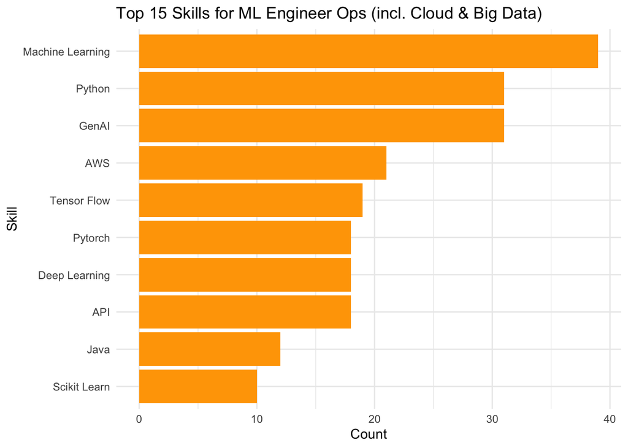

```r
library(dplyr)
library(tidyr)
library(stringr)
library(ggplot2)

skill_counts <- df %>%
  filter(str_detect(edited_category, fixed("ML Engineer Ops (incl. Cloud & Big Data)"))) %>%
  select(
    edited_skills_coding_phyton,
    edited_skills_coding_java,
    edited_skills_coding_cpp,
    edited_skills_coding_sql,
    edited_skills_category_machine_learning,
    edited_skills_category_deep_learning,
    edited_skills_category_LLM,
    edited_skills_category_NLP,
    edited_skills_category_generative_AI,
    edited_skills_category_api,
    edited_skills_category_back_end,
    edited_skills_category_front_end,
    edited_skills_category_full_stack,
    edited_skills_tools_tensor_flow,
    edited_skills_tools_apache_spark,
    edited_skills_tools_pytorch,
    edited_skills_tools_keras,
    edited_skills_tools_Scikit_learn,
    edited_skills_tools_XGBoost,
    edited_skills_tools_AWS,
    edited_skills_tools_Google_Cloud,
    edited_skills_tools_Azure
  ) %>%
  rename(
    `Python` = edited_skills_coding_phyton,
    `Java` = edited_skills_coding_java,
    `C++` = edited_skills_coding_cpp,
    `SQL` = edited_skills_coding_sql,
    `Machine Learning` = edited_skills_category_machine_learning,
    `Deep Learning` = edited_skills_category_deep_learning,
    `LLM` = edited_skills_category_LLM,
    `NLP` = edited_skills_category_NLP,
    `GenAI` = edited_skills_category_generative_AI,
    `API` = edited_skills_category_api,
    `Back-End` = edited_skills_category_back_end,
    `Front-End` = edited_skills_category_front_end,
    `Full-Stack` = edited_skills_category_full_stack,
    `Tensor Flow` = edited_skills_tools_tensor_flow,
    `Apache Spark` = edited_skills_tools_apache_spark,
    `Pytorch` = edited_skills_tools_pytorch,
    `Keras` = edited_skills_tools_keras,
    `Scikit Learn` = edited_skills_tools_Scikit_learn,
    `XGBoost` = edited_skills_tools_XGBoost,
    `AWS` = edited_skills_tools_AWS,
    `Google Cloud` = edited_skills_tools_Google_Cloud,
    `Azure` = edited_skills_tools_Azure
  ) %>%
  pivot_longer(
    cols = everything(),
    names_to = "Skill",
    values_to = "Required"
  ) %>%
  filter(Required == TRUE) %>%
  count(Skill, name = "Count") %>%
  arrange(desc(Count))

# Now plot the top 15 skills with orange bars
skill_counts %>%
  top_n(10, wt = Count) %>%
  ggplot(aes(x = reorder(Skill, Count), y = Count)) +
  geom_bar(stat = "identity", fill = "orange") +
  coord_flip() +
  labs(
    title = "Top 15 Skills for ML Engineer Ops (incl. Cloud & Big Data)",
    x = "Skill",
    y = "Count"
  ) +
  theme_minimal()
```

ML Engineer Ops (incl. Cloud & Big Data) prioritize **Machine Learning, Python** and **Generative AI**, alongside strong cloud and infrastructure skills like **AWS** and **Tensor Flow**. Tools such as **PyTorch, Deep Learning** and **API** support model deployment and system integration, while **Java** and **Scikit Learn** reflect the broader software engineering and data science toolkit needed in this operationally focused role.

### 10.5. ML Engineer Research (incl. Robotics)

Research roles often emphasize deep learning frameworks, algorithmic thinking, and academic-level rigor. We investigate which tools and skills are prioritized in these postings.

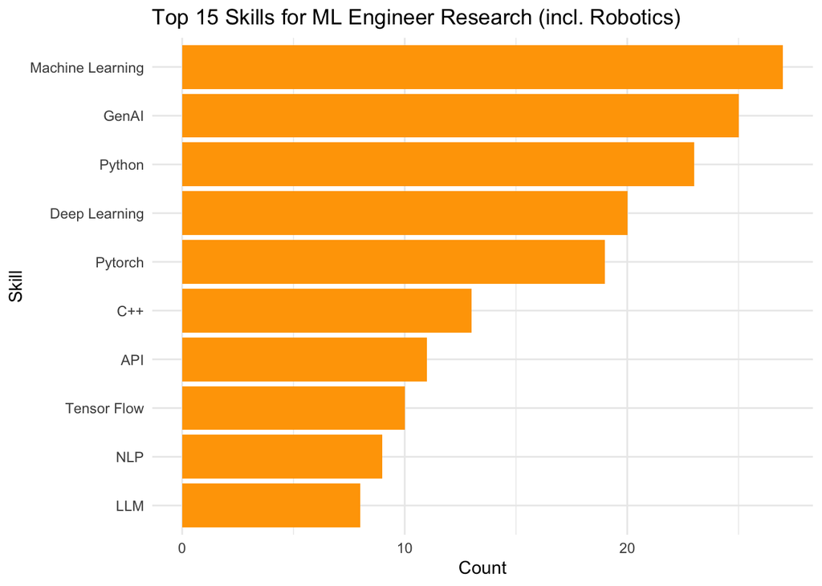

```r
library(dplyr)
library(tidyr)
library(stringr)
library(ggplot2)

skill_counts <- df %>%
  filter(str_detect(edited_category, fixed("ML Engineer Research (incl. Robotics)"))) %>%
  select(
    edited_skills_coding_phyton,
    edited_skills_coding_java,
    edited_skills_coding_cpp,
    edited_skills_coding_sql,
    edited_skills_category_machine_learning,
    edited_skills_category_deep_learning,
    edited_skills_category_LLM,
    edited_skills_category_NLP,
    edited_skills_category_generative_AI,
    edited_skills_category_api,
    edited_skills_category_back_end,
    edited_skills_category_front_end,
    edited_skills_category_full_stack,
    edited_skills_tools_tensor_flow,
    edited_skills_tools_apache_spark,
    edited_skills_tools_pytorch,
    edited_skills_tools_keras,
    edited_skills_tools_Scikit_learn,
    edited_skills_tools_XGBoost,
    edited_skills_tools_AWS,
    edited_skills_tools_Google_Cloud,
    edited_skills_tools_Azure
  ) %>%
  rename(
    `Python` = edited_skills_coding_phyton,
    `Java` = edited_skills_coding_java,
    `C++`= edited_skills_coding_cpp,
    `SQL`= edited_skills_coding_sql,
    `Machine Learning` = edited_skills_category_machine_learning,
    `Deep Learning`= edited_skills_category_deep_learning,
    `LLM` = edited_skills_category_LLM,
    `NLP` = edited_skills_category_NLP,
    `GenAI` = edited_skills_category_generative_AI,
    `API` = edited_skills_category_api,
    `Back-End`= edited_skills_category_back_end,
    `Front-End`= edited_skills_category_front_end,
    `Full-Stack`= edited_skills_category_full_stack,
    `Tensor Flow` = edited_skills_tools_tensor_flow,
    `Apache Spark`= edited_skills_tools_apache_spark,
    `Pytorch`= edited_skills_tools_pytorch,
    `Keras`= edited_skills_tools_keras,
    `Scikit Learn`= edited_skills_tools_Scikit_learn,
    `XGBoost`= edited_skills_tools_XGBoost,
    `AWS`= edited_skills_tools_AWS,
    `Google Cloud`= edited_skills_tools_Google_Cloud,
    `Azure`= edited_skills_tools_Azure
  ) %>%
  pivot_longer(
    cols = everything(),
    names_to = "Skill",
    values_to = "Required"
  ) %>%
  filter(Required == TRUE) %>%
  count(Skill, name = "Count") %>%
  arrange(desc(Count))

# Now plot the top 15 skills with orange bars
skill_counts %>%
  top_n(10, wt = Count) %>%
  ggplot(aes(x = reorder(Skill, Count), y = Count)) +
  geom_bar(stat = "identity", fill = "orange") +
  coord_flip() +
  labs(
    title = "Top 15 Skills for ML Engineer Research (incl. Robotics)",
    x = "Skill",
    y = "Count"
  ) +
  theme_minimal()
```

ML Engineer Research (incl. Robotics) focuses heavily on **Machine Learning** and **Generative AI**, supported by strong programming skills in **Python** and **C++**. Advanced techniques like **Deep Learning** and frameworks such as **PyTorch** and **Tensor Flow** are essential. Communication and integration tools like **API**, along with specialized domains like **NLP** and **LLM**, highlight the cutting-edge nature of these research roles.

### 10.6. ML Engineer / Data Scientist

This section examines the skill requirements for hybrid roles that combine responsibilities from both machine learning engineering and data science. These positions typically demand a versatile set of skills that span programming, statistical analysis and model deployment.

[figure not shown]

```r
library(dplyr)
library(tidyr)
library(stringr)
library(ggplot2)

skill_counts <- df %>%
  filter(str_detect(edited_category, "ML Engineer / Data Scientist")) %>%
  select(
    edited_skills_coding_phyton,
    edited_skills_coding_java,
    edited_skills_coding_cpp,
    edited_skills_coding_sql,
    edited_skills_category_machine_learning,
    edited_skills_category_deep_learning,
    edited_skills_category_LLM,
    edited_skills_category_NLP,
    edited_skills_category_generative_AI,
    edited_skills_category_api,
    edited_skills_category_back_end,
    edited_skills_category_front_end,
    edited_skills_category_full_stack,
    edited_skills_tools_tensor_flow,
    edited_skills_tools_apache_spark,
    edited_skills_tools_pytorch,
    edited_skills_tools_keras,
    edited_skills_tools_Scikit_learn,
    edited_skills_tools_XGBoost,
    edited_skills_tools_AWS,
    edited_skills_tools_Google_Cloud,
    edited_skills_tools_Azure
  ) %>%
  rename(
    `Python` = edited_skills_coding_phyton,
    `Java` = edited_skills_coding_java,
    `C++`= edited_skills_coding_cpp,
    `SQL`= edited_skills_coding_sql,
    `Machine Learning` = edited_skills_category_machine_learning,
    `Deep Learning`= edited_skills_category_deep_learning,
    `LLM` = edited_skills_category_LLM,
    `NLP` = edited_skills_category_NLP,
    `GenAI` = edited_skills_category_generative_AI,
    `API` = edited_skills_category_api,
    `Back-End`= edited_skills_category_back_end,
    `Front-End`= edited_skills_category_front_end,
    `Full-Stack`= edited_skills_category_full_stack,
    `Tensor Flow` = edited_skills_tools_tensor_flow,
    `Apache Spark`= edited_skills_tools_apache_spark,
    `Pytorch`= edited_skills_tools_pytorch,
    `Keras`= edited_skills_tools_keras,
    `Scikit Learn`= edited_skills_tools_Scikit_learn,
    `XGBoost`= edited_skills_tools_XGBoost,
    `AWS`= edited_skills_tools_AWS,
    `Google Cloud`= edited_skills_tools_Google_Cloud,
    `Azure`= edited_skills_tools_Azure
  ) %>%
  pivot_longer(
    cols = everything(),
    names_to = "Skill",
    values_to = "Required"
  ) %>%
  filter(Required == TRUE) %>%
  count(Skill, name = "Count") %>%
  arrange(desc(Count))

# Now plot the top 15 skills with orange bars
skill_counts %>%
  top_n(10, wt = Count) %>%
  ggplot(aes(x = reorder(Skill, Count), y = Count)) +
  geom_bar(stat = "identity", fill = "orange") +
  coord_flip() +
  labs(
    title = "Top 15 Skills for ML Engineer Research (incl. Robotics)",
    x = "Skill",
    y = "Count"
  ) +
  theme_minimal()
```

Compared to other categories, **ML Engineer/ Data Scientist** roles show a stronger focus on **SQL** and **Apache Spark**, highlighting data manipulation and big data skills. While **Machine Learning, Python** and **GenAI** are common across all roles, Data Scientists emphasize querying and data tools more than NLP or Ops engineers. Cloud skills like **AWS** and integration via **API** remain important but less dominant than in Ops roles.

## 11. Job Postings by Skill Profile (PCA)

To conclude, this section uses dimensionality reduction techniques to visually group job postings based on their full skill profiles. It reveals patterns in how skill sets cluster across roles, helping us understand specialization within the AI job market.

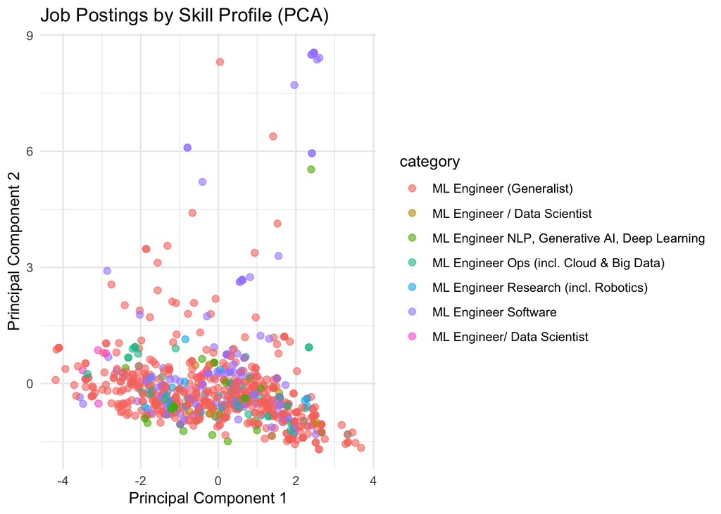

```r
library(dplyr)
library(ggplot2)
library(tidyr)

# 1. Select skill-related columns and group
skills_df <- df %>%
  select(contains("_coding_"), contains("_category_"), contains("_tools_"))

# 2. Optional: give readable column names
colnames(skills_df) <- gsub("edited_skills_", "", colnames(skills_df))

# 3. Convert logicals to numeric (TRUE = 1, FALSE = 0)
skills_numeric <- skills_df %>% mutate(across(everything(), as.integer))

# 4. Run PCA on job posts by skill profile
pca_result <- prcomp(skills_numeric, center = TRUE, scale. = TRUE)

# 5. Take first 2 principal components for plotting
pca_df <- as.data.frame(pca_result$x[, 1:2])
pca_df$category <- df$edited_category  # Add job role label

# 6. Scatter plot
ggplot(pca_df, aes(x = PC1, y = PC2, color = category)) +
  geom_point(alpha = 0.6, size = 2) +
  labs(title = "Job Postings by Skill Profile (PCA)",
       x = "Principal Component 1",
       y = "Principal Component 2") +
  theme_minimal()
```

## 12. Conclusion

The data also shows a consistent preference for technical degrees such as **Computer Science** and **Core Engineering**, with varying emphasis depending on the job type. Emerging AI technologies are clearly shaping hiring patterns, pointing to a future where adaptability and continuous learning are essential.

As AI evolves, this dataset and methodology can be updated to track ongoing changes in roles, skills and locations. Future work might include global job postings, salary analysis or integration with LinkedIn data.